# Week 05 in Statistical machine learning in bioinformatics

Thomas Bataillon

25/02/2021

## ALS dataset

MULTIPLE LINEAR REGRESSION

Load Libraries

```r
# install.packages(c('tibble', 'dplyr', 'tidyr'))
library(tibble)
library(dplyr)
library(tidyr)
library(tidyverse)
library(car)
```

Loading the data

```r
als <- read_rds("datasets/ALS_data_regression/ALS_progression_rate.1822x370.rds")

als_train <- als %>%
  filter(!is.na(dFRS))

als_predict <- als %>%
  filter(is.na(dFRS))


head(als_train)
```

```
## # A tibble: 6 x 370
##     dFRS Onset.Delta Symptom.Speech Symptom.WEAKNESS Symptom.OTHER
##    <dbl>       <dbl>          <dbl>            <dbl>         <dbl>
## 1 -0.915       -1181              1                0             0
## 2 -0.108       -1324              0                1             0
## 3 -0.557       -1061              0                0             0
## 4 -0.296       -1736              0                1             0
## 5 -1.09         -354              1                0             0
## 6 -0.954        -500              1                1             0
## # ... with 365 more variables: Symptom.Swallowing <dbl>,
## #   Symptom.GAIT_CHANGES <dbl>, Symptom.Atrophy <dbl>, Symptom.Cramps <dbl>,
## #   Symptom.Fasciculations <dbl>, Symptom.SENSORY_CHANGES <dbl>,
## #   Symptom.Stiffness <dbl>, Symptom.. <dbl>,
## #   Site.of.Onset.Onset..Bulbar <dbl>, Site.of.Onset.Onset..Limb <dbl>,
## #   Site.of.Onset.Onset..Limb.and.Bulbar <dbl>, Race...Asian <dbl>,
## #   Race...Black.African.American <dbl>, Race...Caucasian <dbl>,
## #   Race...Other <dbl>, Age <dbl>, Sex.Female <dbl>, Sex.Male <dbl>,
## #   Aunt <dbl>, Aunt..Maternal. <dbl>, Cousin <dbl>, Father <dbl>,
## #   Grandfather..Maternal. <dbl>, Grandmother <dbl>,
## #   Grandmother..Maternal. <dbl>, Mother <dbl>, Uncle <dbl>,
## #   Uncle..Maternal. <dbl>, Uncle..Paternal. <dbl>, Son <dbl>, Daughter <dbl>,
## #   Sister <dbl>, Brother <dbl>, Family <dbl>,
## #   Neurological.Disease.OTHER <dbl>, Neurological.Disease.STROKE.NOS <dbl>,
## #   Neurological.Disease.DEMENTIA.NOS <dbl>,
## #   Neurological.Disease.PARKINSON.S.DISEASE <dbl>,
## #   Neurological.Disease.DAT <dbl>, Neurological.Disease.ALS <dbl>,
## #   Neurological.Disease.BRAIN.TUMOR <dbl>,
## #   Neurological.Disease.STROKE.ISCHEMIC <dbl>,
## #   Neurological.Disease.STROKE.HEMORRHAGIC <dbl>, Study.Arm.PLACEBO <dbl>,
## #   Study.Arm.ACTIVE <dbl>, max.alsfrs.score <dbl>, min.alsfrs.score <dbl>,
## #   last.alsfrs.score <dbl>, mean.alsfrs.score <dbl>,
## #   num.alsfrs.score.visits <dbl>, sum.alsfrs.score <dbl>,
## #   first.alsfrs.score.date <dbl>, last.alsfrs.score.date <dbl>,
## #   meansquares.alsfrs.score <dbl>, sd.alsfrs.score <dbl>,
## #   alsfrs.score.slope <dbl>, lessthan2.alsfrs.score <dbl>,
## #   no.alsfrs.score.data <dbl>, max.speech <dbl>, min.speech <dbl>,
## #   last.speech <dbl>, mean.speech <dbl>, sum.speech <dbl>,
## #   meansquares.speech <dbl>, sd.speech <dbl>, speech.slope <dbl>,
## #   max.salivation <dbl>, min.salivation <dbl>, last.salivation <dbl>,
## #   mean.salivation <dbl>, sum.salivation <dbl>, meansquares.salivation <dbl>,
## #   sd.salivation <dbl>, salivation.slope <dbl>, max.swallowing <dbl>,
## #   min.swallowing <dbl>, last.swallowing <dbl>, mean.swallowing <dbl>,
## #   sum.swallowing <dbl>, meansquares.swallowing <dbl>, sd.swallowing <dbl>,
## #   swallowing.slope <dbl>, max.handwriting <dbl>, min.handwriting <dbl>,
## #   last.handwriting <dbl>, mean.handwriting <dbl>, sum.handwriting <dbl>,
## #   meansquares.handwriting <dbl>, sd.handwriting <dbl>,
## #   handwriting.slope <dbl>, max.cutting <dbl>, min.cutting <dbl>,
## #   last.cutting <dbl>, mean.cutting <dbl>, sum.cutting <dbl>,
## #   meansquares.cutting <dbl>, sd.cutting <dbl>, cutting.slope <dbl>,
## #   max.dressing <dbl>, min.dressing <dbl>, ...
```

```r
head(als_predict)
```

```
## # A tibble: 6 x 370
##    dFRS Onset.Delta Symptom.Speech Symptom.WEAKNESS Symptom.OTHER
##   <dbl>       <dbl>          <dbl>            <dbl>         <dbl>
## 1    NA        -408              0                1             0
## 2    NA        -959              0                0             0
## 3    NA        -677              0                1             0
## 4    NA        -278              0                0             0
## 5    NA        -808              0                0             0
## 6    NA        -480              0                1             0
## # ... with 365 more variables: Symptom.Swallowing <dbl>,
## #   Symptom.GAIT_CHANGES <dbl>, Symptom.Atrophy <dbl>, Symptom.Cramps <dbl>,
## #   Symptom.Fasciculations <dbl>, Symptom.SENSORY_CHANGES <dbl>,
## #   Symptom.Stiffness <dbl>, Symptom.. <dbl>,
## #   Site.of.Onset.Onset..Bulbar <dbl>, Site.of.Onset.Onset..Limb <dbl>,
## #   Site.of.Onset.Onset..Limb.and.Bulbar <dbl>, Race...Asian <dbl>,
## #   Race...Black.African.American <dbl>, Race...Caucasian <dbl>,
## #   Race...Other <dbl>, Age <dbl>, Sex.Female <dbl>, Sex.Male <dbl>,
## #   Aunt <dbl>, Aunt..Maternal. <dbl>, Cousin <dbl>, Father <dbl>,
## #   Grandfather..Maternal. <dbl>, Grandmother <dbl>,
## #   Grandmother..Maternal. <dbl>, Mother <dbl>, Uncle <dbl>,
## #   Uncle..Maternal. <dbl>, Uncle..Paternal. <dbl>, Son <dbl>, Daughter <dbl>,
## #   Sister <dbl>, Brother <dbl>, Family <dbl>,
## #   Neurological.Disease.OTHER <dbl>, Neurological.Disease.STROKE.NOS <dbl>,
## #   Neurological.Disease.DEMENTIA.NOS <dbl>,
## #   Neurological.Disease.PARKINSON.S.DISEASE <dbl>,
## #   Neurological.Disease.DAT <dbl>, Neurological.Disease.ALS <dbl>,
## #   Neurological.Disease.BRAIN.TUMOR <dbl>,
## #   Neurological.Disease.STROKE.ISCHEMIC <dbl>,
## #   Neurological.Disease.STROKE.HEMORRHAGIC <dbl>, Study.Arm.PLACEBO <dbl>,
## #   Study.Arm.ACTIVE <dbl>, max.alsfrs.score <dbl>, min.alsfrs.score <dbl>,
## #   last.alsfrs.score <dbl>, mean.alsfrs.score <dbl>,
## #   num.alsfrs.score.visits <dbl>, sum.alsfrs.score <dbl>,
## #   first.alsfrs.score.date <dbl>, last.alsfrs.score.date <dbl>,
## #   meansquares.alsfrs.score <dbl>, sd.alsfrs.score <dbl>,
## #   alsfrs.score.slope <dbl>, lessthan2.alsfrs.score <dbl>,
## #   no.alsfrs.score.data <dbl>, max.speech <dbl>, min.speech <dbl>,
## #   last.speech <dbl>, mean.speech <dbl>, sum.speech <dbl>,
## #   meansquares.speech <dbl>, sd.speech <dbl>, speech.slope <dbl>,
## #   max.salivation <dbl>, min.salivation <dbl>, last.salivation <dbl>,
## #   mean.salivation <dbl>, sum.salivation <dbl>, meansquares.salivation <dbl>,
## #   sd.salivation <dbl>, salivation.slope <dbl>, max.swallowing <dbl>,
## #   min.swallowing <dbl>, last.swallowing <dbl>, mean.swallowing <dbl>,
## #   sum.swallowing <dbl>, meansquares.swallowing <dbl>, sd.swallowing <dbl>,
## #   swallowing.slope <dbl>, max.handwriting <dbl>, min.handwriting <dbl>,
## #   last.handwriting <dbl>, mean.handwriting <dbl>, sum.handwriting <dbl>,
## #   meansquares.handwriting <dbl>, sd.handwriting <dbl>,
## #   handwriting.slope <dbl>, max.cutting <dbl>, min.cutting <dbl>,
## #   last.cutting <dbl>, mean.cutting <dbl>, sum.cutting <dbl>,
## #   meansquares.cutting <dbl>, sd.cutting <dbl>, cutting.slope <dbl>,
## #   max.dressing <dbl>, min.dressing <dbl>, ...
```

```r
sum(is.na(als_train))
```

```
## [1] 0
```

We can make a correlation matrix to take a peek at how much correlation between the predictors we observe

```r
correlation_matrix<-cor(als_train)
```

> Q Use multiple linear regression for making prediction on the ALS rsponse variable

```r
#Make model with ALL predictors (We should check which are more important)

mlg <- lm(dFRS~.,data=als_train)
summary(mlg$coefficients)
```

```
##      Min.   1st Qu.    Median      Mean   3rd Qu.      Max.      NA's
## -2.993513 -0.062087  0.001412  0.020238  0.095627  4.155433         9
```

```r
summary(mlg)
```

```
##
## Call:
## lm(formula = dFRS ~ ., data = als_train)
##
## Residuals:
##      Min       1Q   Median       3Q      Max
## -1.83068 -0.25024  0.02248  0.29555  1.83568
##
## Coefficients: (9 not defined because of singularities)
##                                            Estimate Std. Error t value Pr(>|t|)
## (Intercept)                               4.155e+00  7.226e+00   0.575 0.565363
## Onset.Delta                              -4.197e-04  3.760e-05 -11.162  < 2e-16
## Symptom.Speech                           -5.896e-03  7.815e-02  -0.075 0.939873
## Symptom.WEAKNESS                         -4.417e-02  7.107e-02  -0.621 0.534420
## Symptom.OTHER                             1.309e-01  9.564e-02   1.368 0.171457
## Symptom.Swallowing                        4.528e-02  1.168e-01   0.388 0.698276
## Symptom.GAIT_CHANGES                     -1.136e-02  1.647e-01  -0.069 0.945013
## Symptom.Atrophy                           8.844e-02  1.016e-01   0.870 0.384320
## Symptom.Cramps                            2.648e-02  9.001e-02   0.294 0.768700
## Symptom.Fasciculations                   -5.513e-02  9.101e-02  -0.606 0.544782
## Symptom.SENSORY_CHANGES                   4.057e-02  1.275e-01   0.318 0.750419
## Symptom.Stiffness                         2.210e-01  1.184e-01   1.867 0.062158
## Symptom..                                -2.193e-01  2.120e-01  -1.034 0.301236
## Site.of.Onset.Onset..Bulbar              -2.276e-01  1.998e-01  -1.139 0.254770
## Site.of.Onset.Onset..Limb                -2.113e-01  2.024e-01  -1.044 0.296754
## Site.of.Onset.Onset..Limb.and.Bulbar             NA         NA      NA       NA
## Race...Asian                              7.504e-03  3.502e-01   0.021 0.982907
## Race...Black.African.American             3.175e-02  3.362e-01   0.094 0.924764
## Race...Caucasian                         -8.292e-02  3.160e-01  -0.262 0.793078
## Race...Other                             -2.307e-01  3.392e-01  -0.680 0.496474
## Age                                      -7.591e-04  1.519e-03  -0.500 0.617293
## Sex.Female                               -1.672e-01  7.995e-02  -2.091 0.036724
## Sex.Male                                 -1.175e-01  7.493e-02  -1.568 0.117191
## Aunt                                     -6.799e-02  1.929e-01  -0.352 0.724527
## Aunt..Maternal.                          -7.618e-02  2.658e-01  -0.287 0.774437
## Cousin                                    4.248e-01  2.313e-01   1.837 0.066472
## Father                                    2.785e-02  9.831e-02   0.283 0.776997
## Grandfather..Maternal.                   -3.749e-02  3.942e-01  -0.095 0.924262
## Grandmother                               1.748e-01  1.909e-01   0.916 0.359950
## Grandmother..Maternal.                    3.046e-01  3.363e-01   0.906 0.365218
```

[output cut: 702 more lines]

```
## min.slope.bp.systolic
## last.slope.bp.systolic
## mean.slope.bp.systolic
## num.slope.bp.systolic.visits
## sum.slope.bp.systolic
## first.slope.bp.systolic.date
## meansquares.slope.bp.systolic
## sd.slope.bp.systolic
## slope.bp.systolic.slope
## ---
## Signif. codes:  0 '***' 0.001 '**' 0.01 '*' 0.05 '.' 0.1 ' ' 1
##
## Residual standard error: 0.477 on 1261 degrees of freedom
## Multiple R-squared:  0.4437, Adjusted R-squared:  0.2848
## F-statistic: 2.793 on 360 and 1261 DF,  p-value: < 2.2e-16
```

```r
#We observe 9 predictors which give NA, we will remove them manually from our model

mlg <- lm(dFRS~. -Site.of.Onset.Onset..Limb.and.Bulbar -mean.height -sd.height -no.height.data -no.resp.rate.data -no.bp.diastolic.data -no.slope.fvc.liters.data -first.slope.height.date -num.slope.bp.systolic.visits,data=als_train)


#If we run vif we can see which ones we should remove.
all_vifs<-car::vif(mlg)
signif_all <- names(all_vifs)

# Remove vars with VIF> 4 and re-build model until none of VIFs don't exceed 4.
while(any(all_vifs > 4)){
  var_with_max_vif <- names(which(all_vifs == max(all_vifs)))  # get the var with max vif
  signif_all <- signif_all[!(signif_all) %in% var_with_max_vif]  # remove
  myForm <- as.formula(paste("dFRS ~ ", paste (signif_all, collapse=" + "), sep=""))  # new formula
  mlg <- lm(myForm, data=als_train)  # re-build model with new formula
  all_vifs <- car::vif(mlg)
}
summary(mlg)
```

```
##
## Call:
## lm(formula = myForm, data = als_train)
##
## Residuals:
##      Min       1Q   Median       3Q      Max
## -1.96146 -0.27362  0.04253  0.32048  2.00846
##
## Coefficients:
##                                            Estimate Std. Error t value Pr(>|t|)
## (Intercept)                               1.750e-01  4.194e-01   0.417 0.676595
## Onset.Delta                              -4.275e-04  3.518e-05 -12.151  < 2e-16
## Symptom.Speech                            9.415e-03  5.603e-02   0.168 0.866581
## Symptom.OTHER                             1.496e-01  9.134e-02   1.638 0.101580
## Symptom.Swallowing                        8.652e-03  1.114e-01   0.078 0.938129
## Symptom.GAIT_CHANGES                     -3.711e-03  1.616e-01  -0.023 0.981686
## Symptom.Atrophy                           1.133e-01  9.804e-02   1.156 0.247819
## Symptom.Cramps                            1.486e-02  8.660e-02   0.172 0.863802
## Symptom.Fasciculations                   -9.999e-02  8.749e-02  -1.143 0.253265
## Symptom.SENSORY_CHANGES                   4.588e-02  1.238e-01   0.371 0.711051
## Symptom.Stiffness                         2.227e-01  1.118e-01   1.992 0.046587
## Symptom..                                -3.849e-02  2.092e-01  -0.184 0.854079
## Site.of.Onset.Onset..Bulbar              -8.337e-02  5.435e-02  -1.534 0.125261
## Race...Asian                              1.124e-01  1.443e-01   0.779 0.435969
## Race...Black.African.American             1.041e-01  1.092e-01   0.953 0.340755
## Race...Other                             -9.116e-02  1.127e-01  -0.809 0.418540
## Age                                      -2.147e-04  1.402e-03  -0.153 0.878326
## Sex.Female                               -1.152e-01  4.695e-02  -2.453 0.014268
## Sex.Male                                 -5.331e-02  4.302e-02  -1.239 0.215485
## Aunt                                      5.184e-02  1.881e-01   0.276 0.782852
## Aunt..Maternal.                           3.875e-02  2.584e-01   0.150 0.880818
## Cousin                                    4.808e-01  2.190e-01   2.196 0.028267
## Father                                    8.147e-02  9.305e-02   0.875 0.381461
## Grandfather..Maternal.                    1.660e-01  3.904e-01   0.425 0.670671
## Grandmother                               1.363e-01  1.869e-01   0.729 0.466206
## Grandmother..Maternal.                    3.888e-01  2.872e-01   1.354 0.175987
## Mother                                    3.021e-02  8.392e-02   0.360 0.718890
## Uncle                                     1.095e-01  1.986e-01   0.551 0.581550
## Uncle..Maternal.                          3.891e-01  3.234e-01   1.203 0.229132
## Uncle..Paternal.                          4.379e-01  5.177e-01   0.846 0.397853
```

[output cut: 272 more lines]

```
## meansquares.slope.resp.rate
## slope.resp.rate.slope
## last.slope.bp.diastolic
## sum.slope.bp.diastolic
## meansquares.slope.bp.diastolic
## slope.bp.diastolic.slope
## max.slope.bp.systolic
## last.slope.bp.systolic
## slope.bp.systolic.slope
## ---
## Signif. codes:  0 '***' 0.001 '**' 0.01 '*' 0.05 '.' 0.1 ' ' 1
##
## Residual standard error: 0.4966 on 1467 degrees of freedom
## Multiple R-squared:  0.2986, Adjusted R-squared:  0.2249
## F-statistic: 4.055 on 154 and 1467 DF,  p-value: < 2.2e-16
```

```r
car::vif(mlg)
```

```
##                              Onset.Delta
##                                 1.378717
##                           Symptom.Speech
##                                 1.825721
##                            Symptom.OTHER
##                                 1.125986
##                       Symptom.Swallowing
##                                 1.288363
##                     Symptom.GAIT_CHANGES
##                                 1.157504
##                          Symptom.Atrophy
##                                 1.109934
##                           Symptom.Cramps
##                                 1.128370
##                   Symptom.Fasciculations
##                                 1.151707
##                  Symptom.SENSORY_CHANGES
##                                 1.106740
##                        Symptom.Stiffness
##                                 1.149237
##                                Symptom..
##                                 1.061004
##              Site.of.Onset.Onset..Bulbar
##                                 3.225796
##                             Race...Asian
##                                 1.088667
##            Race...Black.African.American
##                                 1.097044
##                             Race...Other
##                                 1.116844
##                                      Age
##                                 1.682465
##                               Sex.Female
##                                 2.196262
##                                 Sex.Male
##                                 2.725225
##                                     Aunt
##                                 1.283535
##                          Aunt..Maternal.
##                                 1.349471
```

[output cut: 253 more lines]

```
##                                 2.020679
##                  last.slope.bp.diastolic
##                                 2.771155
##                   sum.slope.bp.diastolic
##                                 3.178534
##           meansquares.slope.bp.diastolic
##                                 1.636606
##                 slope.bp.diastolic.slope
##                                 3.634649
##                    max.slope.bp.systolic
##                                 2.224046
##                   last.slope.bp.systolic
##                                 2.050851
##                  slope.bp.systolic.slope
##                                 2.397482
```

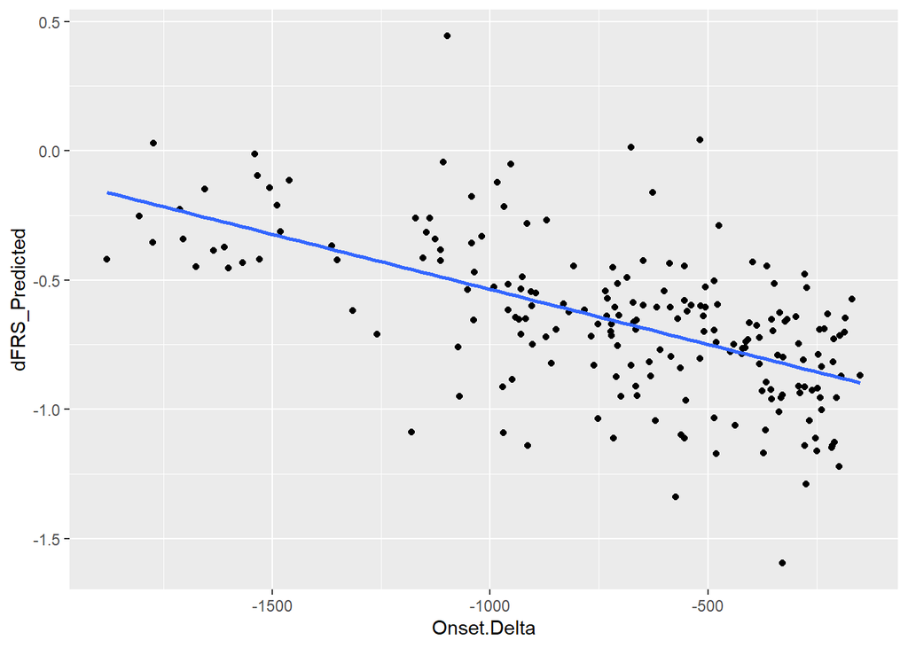

```r
#Predict dFRS on our predict dataframe
glm_als_predict<-als_predict
glm_als_predict$dFRS_Predicted = predict.glm(mlg, glm_als_predict, type = "response")

#Plot the fit using Onset.Delta since it is continuous
ggplot(glm_als_predict, aes(x=Onset.Delta, y=dFRS_Predicted)) +
  geom_point() +
  geom_smooth(method = "glm", se = FALSE) +
  NULL
```

> Q use cross validation to examine how accurate are the predictions you can make

```r
# Function for calculating the 10-fold CV error
cross_validation <- function(dataset, k=10){

  cvfolds <- cut(seq_len(nrow(dataset)), breaks = k, labels = FALSE)  # Generate breaks
  cvfolds <- sample(cvfolds)                                      # Randomize breaks

  observed  <- dataset$dFRS                                       # Get observed values
  predicted <- rep(NA, nrow(dataset))                             # Empty vector for predicted values

  for (i in 1:k){                                                 # For each fold
    rows      <- which(cvfolds==i)                                # Get values belonging to that fold
    testdata  <- dataset[rows,]                                   # Get test values
    traindata <- dataset[-rows,]                                  # Get training values
    fit       <- lm(myForm, data=traindata)                       # Fit the model with training data
    tmp       <- predict(fit,newdata = testdata)                  # Predict on test data
    predicted[rows] <- tmp                                        # Add predictions to vector
  }

  rmse_cv <- sqrt(mean((observed-predicted)^2))        # Calculate CV RMSE

    fit        <- lm(dFRS~., data=dataset)                          # Fit the model with all the dataset
  observed   <- dataset$dFRS                                      # Get observed values
  predicted  <- predict(fit,newdata = dataset)                    # Get predicted values
  rmse_train <- sqrt(mean((observed-predicted)^2))     # Calculate training RMSE

  return(c(rmse_cv, rmse_train))                                  # Return CV and training RMSEs
}

pd <- tibble(run=1:5)                                             # Empty tibble for five different runs

for (i in pd$run) {                                               # For each of the runs
  set.seed(i)
  r <- cross_validation(als_train, 10)                             # Run the CV analysis
  pd$rmse_cv[i] <- r[1]                                           # Save the CV RMSE
  pd$rmse_train <- r[2]                                           # Save the training RMSE
  cat("Run", i, "\n")                                             # Print status
  flush.console()
}
```

```
## Run 1
```

```
## Run 2
```

```
## Run 3
```

```
## Run 4
```

```
## Run 5
```

```r
knitr::kable(pd)
```

| run | rmse_cv | rmse_train |
| --- | --- | --- |
| 1 | 0.5563645 | 0.4206154 |
| 2 | 0.5559178 | 0.4206154 |
| 3 | 0.5441703 | 0.4206154 |
| 4 | 0.5506628 | 0.4206154 |
| 5 | 0.5624970 | 0.4206154 |

> Q Upload yourbest predictions as a TEAM using a rds format

## TCGA dataset

> Q Apply classication methods to the TCGA datset for making prediction on samples

You can use any method we have covered so far (i.e. logistic regression , LDA QDA or even KNN) and use any predictors from the TCGA dataset.

CANCER-> Logistic TISSUE-> LDA or QDA

> Q use cross validation to examine how accurate are the predictions you can make

> Q Apply QDA to the TCGA datset for making prediction on tissues samples

> Q submit your best predictions as a TEAM using a rds format